# Brain Cancer Classification — Gene Expression (GSE50161)

**Pipeline:** StandardScaler → PCA → Random Forest | Decision Tree | KNN

*Dedicated to my grandmother, whose battle with brain cancer inspired this project.*

## 1. Import Libraries

```python
import pandas as pd
import numpy as np
import matplotlib.pyplot as plt
import warnings
warnings.filterwarnings('ignore')  # keeps output clean

from sklearn.preprocessing import StandardScaler, LabelEncoder
from sklearn.decomposition import PCA
from sklearn.ensemble import RandomForestClassifier
from sklearn.tree import DecisionTreeClassifier
from sklearn.neighbors import KNeighborsClassifier
from sklearn.model_selection import train_test_split
from xgboost import XGBClassifier
import matplotlib.pyplot as plt
from sklearn.preprocessing import label_binarize
from sklearn.metrics import roc_curve, auc
from sklearn.utils.class_weight import compute_sample_weight

from sklearn.metrics import (accuracy_score, classification_report,
                             confusion_matrix, ConfusionMatrixDisplay)
import joblib
```

## 2. Load Dataset

```python
df = pd.read_csv("Brain_GSE50161.csv")
print(f"Dataset shape: {df.shape}")
print(f"Tumor type counts:")
print(df["type"].value_counts().to_string())
```

```
Dataset shape: (130, 54677)
Tumor type counts:
type
ependymoma               46
glioblastoma             34
medulloblastoma          22
pilocytic_astrocytoma    15
normal                   13
```

## 3. Preview the Data

```python
df.iloc[:5, :7]  # first 5 rows, first 7 columns
```

|  | samples | type | 1007_s_at | 1053_at | 117_at | 121_at | 1255_g_at |
| --- | --- | --- | --- | --- | --- | --- | --- |
| 0 | 834 | ependymoma | 12.498150 | 7.604868 | 6.880934 | 9.027128 | 4.176175 |
| 1 | 835 | ependymoma | 13.067436 | 7.998090 | 7.209076 | 9.723322 | 4.826126 |
| 2 | 836 | ependymoma | 13.068179 | 8.573674 | 8.647684 | 9.613002 | 4.396581 |
| 3 | 837 | ependymoma | 12.456040 | 9.098977 | 6.628784 | 8.517677 | 4.154847 |
| 4 | 838 | ependymoma | 12.699958 | 8.800721 | 11.556188 | 9.166309 | 4.165891 |

## 4. Prepare Features (X) and Labels (y)

```python
X = df.drop(columns=["samples", "type"]).values
y = df["type"].values

le = LabelEncoder()
y_encoded = le.fit_transform(y)

print("Classes:", list(le.classes_))
print("Encoded:", list(range(len(le.classes_))))
```

```
Classes: ['ependymoma', 'glioblastoma', 'medulloblastoma', 'normal', 'pilocytic_astrocytoma']
Encoded: [0, 1, 2, 3, 4]
```

## 5. Train / Test Split

```python
X_train, X_test, y_train, y_test = train_test_split(
    X, y_encoded, test_size=0.2, random_state=42, stratify=y_encoded
)

print(f"Train size: {X_train.shape[0]} patients")
print(f"Test size:  {X_test.shape[0]} patients")
```

```
Train size: 104 patients
Test size:  26 patients
```

## 6. StandardScaler

Gene expression values vary widely across genes.

```python
scaler = StandardScaler()
X_train_scaled = scaler.fit_transform(X_train)   # fit + transform on train
X_test_scaled  = scaler.transform(X_test)         # only transform on test

print(f"Mean of first gene (train): {X_train_scaled[:, 0].mean():.4f} ")
print(f"Std  of first gene (train): {X_train_scaled[:, 0].std():.4f}  ")
```

```
Mean of first gene (train): -0.0000
Std  of first gene (train): 1.0000
```

## 7. PCA — Dimensionality Reduction

54,000 genes is far too many for a classifier. PCA compresses them into 50 **principal components** that capture the most variation.

Think of it as finding the 50 most informative "directions" in the data.

```python
pca = PCA(n_components=50, random_state=42)
X_train_pca = pca.fit_transform(X_train_scaled)
X_test_pca  = pca.transform(X_test_scaled)

explained = pca.explained_variance_ratio_.cumsum()[-1] * 100
print(f"50 components explain {explained:.1f}% of the original variance")
print(f"Shape before PCA: {X_train_scaled.shape}")
print(f"Shape after PCA:  {X_train_pca.shape}")
```

```
50 components explain 87.1% of the original variance
Shape before PCA: (104, 54675)
Shape after PCA:  (104, 50)
```

### PCA — Cumulative Explained Variance Plot

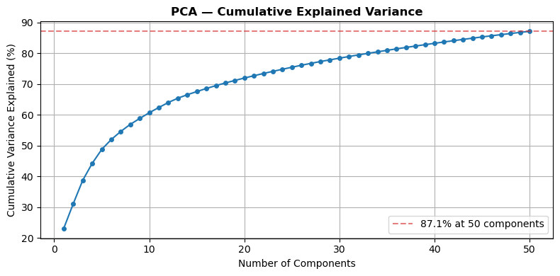

```python
plt.figure(figsize=(8, 4))
plt.plot(range(1, 51), pca.explained_variance_ratio_.cumsum() * 100, "o-", markersize=4)
plt.axhline(y=explained, color="tab:red", linestyle="--", alpha=0.6, label=f"{explained:.1f}% at 50 components")
plt.title("PCA — Cumulative Explained Variance", fontweight="bold")
plt.xlabel("Number of Components")
plt.ylabel("Cumulative Variance Explained (%)")
plt.legend()
plt.grid(True)
plt.tight_layout()
plt.show()
```

### PCA — First 2 Components Colored by Tumor Type

This shows whether the 5 tumor types are separable in 2D gene-expression space.

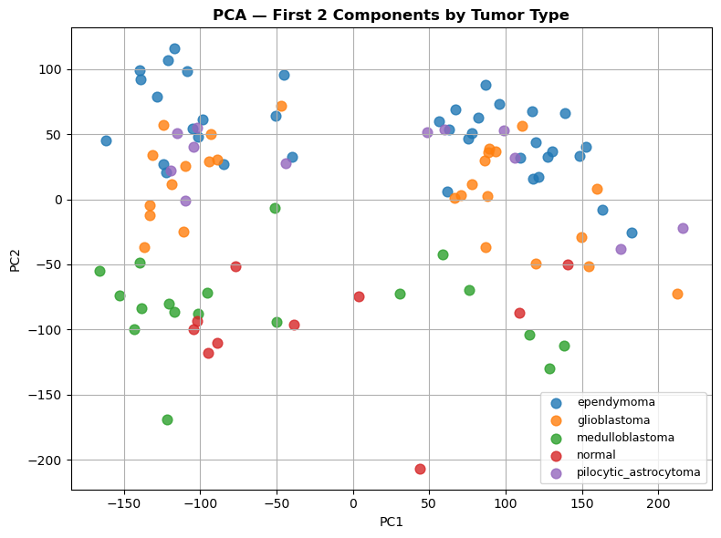

```python
plt.figure(figsize=(8, 6))
for label, name in enumerate(le.classes_):
    mask = y_train == label
    plt.scatter(X_train_pca[mask, 0], X_train_pca[mask, 1],
                label=name, alpha=0.8, s=60)
plt.title("PCA — First 2 Components by Tumor Type", fontweight="bold")
plt.xlabel("PC1")
plt.ylabel("PC2")
plt.legend(fontsize=9)
plt.grid(True)
plt.tight_layout()
plt.show()
```

## Why Try Multiple Models?

There is no single 'best' model for every dataset. Different algorithms make different assumptions about the data, so the only way to know which one works best for *your* problem is to **run them all and compare**.

We will now test two more classifiers on the same PCA-reduced data:

- **Decision Tree** — easy to interpret, makes yes/no splits on features
- **K-Nearest Neighbors (KNN)** — classifies each patient based on its closest neighbors

## 8. Train Random Forest Classifier

```python
rf = RandomForestClassifier(
    n_estimators=200,
    class_weight="balanced",
    random_state=42
)
rf.fit(X_train_pca, y_train)
print("Random Forest trained successfully!")
```

```
Random Forest trained successfully!
```

## 9. Evaluate the Model

```python
y_pred = rf.predict(X_test_pca)

acc = accuracy_score(y_test, y_pred) * 100
print(f"Accuracy: {acc:.2f}%")
print()
print("Classification Report:")
print(classification_report(y_test, y_pred, target_names=le.classes_))
```

```
Accuracy: 88.46%

Classification Report:
                       precision    recall  f1-score   support

           ependymoma       0.80      0.89      0.84         9
         glioblastoma       1.00      1.00      1.00         7
      medulloblastoma       1.00      0.50      0.67         4
               normal       1.00      1.00      1.00         3
pilocytic_astrocytoma       0.75      1.00      0.86         3

             accuracy                           0.88        26
            macro avg       0.91      0.88      0.87        26
         weighted avg       0.90      0.88      0.88        26
```

### Confusion Matrix

Rows = actual tumor type, Columns = predicted tumor type. Diagonal = correct predictions.

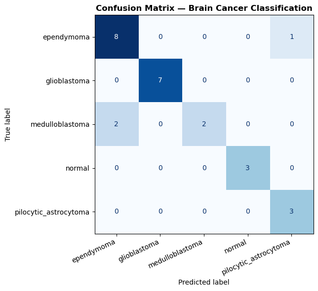

```python
cm = confusion_matrix(y_test, y_pred)
fig, ax = plt.subplots(figsize=(7, 6))
disp = ConfusionMatrixDisplay(confusion_matrix=cm, display_labels=le.classes_)
disp.plot(ax=ax, colorbar=False, cmap="Blues")
plt.title("Confusion Matrix — Brain Cancer Classification", fontweight="bold")
plt.xticks(rotation=25, ha="right")
plt.tight_layout()
plt.show()
```

## 11. Decision Tree Classifier

- `max_depth=10` → limits how deep the tree grows (prevents overfitting)
- `class_weight='balanced'` → handles the unequal class sizes in our dataset
- `random_state=42` → reproducible results

```python
# ── Train Decision Tree ──────────────────────────────────────────────
dt = DecisionTreeClassifier(
    max_depth=10,
    class_weight='balanced',
    random_state=42
)
dt.fit(X_train_pca, y_train)

# ── Predictions ──────────────────────────────────────────────────────
y_pred_dt = dt.predict(X_test_pca)

# ── Accuracy ─────────────────────────────────────────────────────────
acc_dt = accuracy_score(y_test, y_pred_dt) * 100
print(f"Decision Tree Accuracy: {acc_dt:.2f}%")
print()
print("=" * 55)
print("Classification Report — Decision Tree")
print("=" * 55)
print(classification_report(y_test, y_pred_dt, target_names=le.classes_))
```

```
Decision Tree Accuracy: 84.62%

=======================================================
Classification Report — Decision Tree
=======================================================
                       precision    recall  f1-score   support

           ependymoma       0.80      0.89      0.84         9
         glioblastoma       0.86      0.86      0.86         7
      medulloblastoma       1.00      0.50      0.67         4
               normal       1.00      1.00      1.00         3
pilocytic_astrocytoma       0.75      1.00      0.86         3

             accuracy                           0.85        26
            macro avg       0.88      0.85      0.84        26
         weighted avg       0.86      0.85      0.84        26
```

### Confusion Matrix — Decision Tree

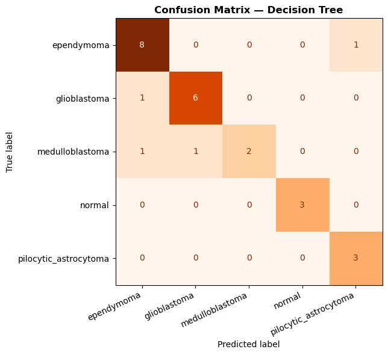

```python
cm_dt = confusion_matrix(y_test, y_pred_dt)

fig, ax = plt.subplots(figsize=(7, 6))
disp = ConfusionMatrixDisplay(confusion_matrix=cm_dt, display_labels=le.classes_)
disp.plot(ax=ax, colorbar=False, cmap='Oranges')
plt.title("Confusion Matrix — Decision Tree", fontweight="bold")
plt.xticks(rotation=25, ha="right")
plt.tight_layout()
plt.show()
```

## 12. K-Nearest Neighbors (KNN) Classifier

- `n_neighbors=5` → look at the 5 closest training samples
- `metric='euclidean'` → measure distance in PCA space
- `weights='distance'` → closer neighbors get a stronger vote

> KNN is very sensitive to scale, which is why scaling + PCA first was important.

```python
# ── Train KNN ────────────────────────────────────────────────────────
knn = KNeighborsClassifier(
    n_neighbors=5,
    metric='euclidean',
    weights='distance'
)
knn.fit(X_train_pca, y_train)

# ── Predictions ──────────────────────────────────────────────────────
y_pred_knn = knn.predict(X_test_pca)

# ── Accuracy ─────────────────────────────────────────────────────────
acc_knn = accuracy_score(y_test, y_pred_knn) * 100
print(f"KNN Accuracy: {acc_knn:.2f}%")
print()
print("=" * 55)
print("Classification Report — KNN")
print("=" * 55)
print(classification_report(y_test, y_pred_knn, target_names=le.classes_))
```

```
KNN Accuracy: 84.62%

=======================================================
Classification Report — KNN
=======================================================
                       precision    recall  f1-score   support

           ependymoma       0.80      0.89      0.84         9
         glioblastoma       1.00      0.86      0.92         7
      medulloblastoma       1.00      0.50      0.67         4
               normal       1.00      1.00      1.00         3
pilocytic_astrocytoma       0.60      1.00      0.75         3

             accuracy                           0.85        26
            macro avg       0.88      0.85      0.84        26
         weighted avg       0.88      0.85      0.84        26
```

### Confusion Matrix — KNN

Same layout as before — diagonal = correct, off-diagonal = mistakes.

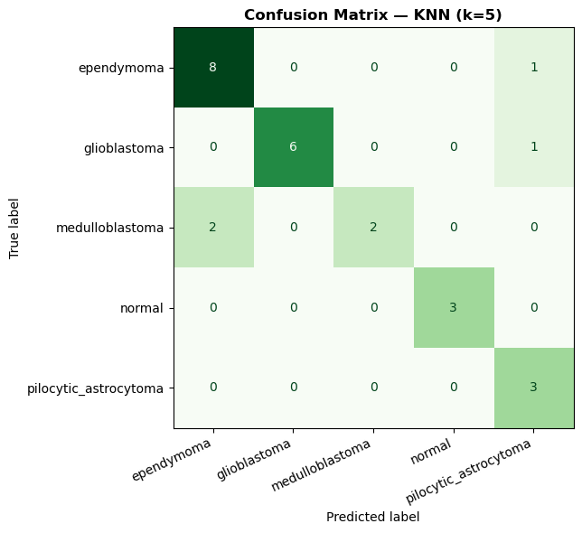

```python
cm_knn = confusion_matrix(y_test, y_pred_knn)

fig, ax = plt.subplots(figsize=(7, 6))
disp = ConfusionMatrixDisplay(confusion_matrix=cm_knn, display_labels=le.classes_)
disp.plot(ax=ax, colorbar=False, cmap='Greens')
plt.title("Confusion Matrix — KNN (k=5)", fontweight="bold")
plt.xticks(rotation=25, ha="right")
plt.tight_layout()
plt.show()
```

## 13. XGBoost

```python
# ── Calculate the dynamic class-balancing weights ────────────────────
sample_weights = compute_sample_weight(class_weight='balanced', y=y_train)

# ── Train with Weights ───────────────────────────────────────────────
xgb = XGBClassifier(
    n_estimators=100,
    learning_rate=0.1,
    max_depth=4,
    objective='multi:softprob',
    random_state=42
)
xgb.fit(X_train_pca, y_train, sample_weight=sample_weights)

# ── Predictions ──────────────────────────────────────────────────────
y_pred_xgb = xgb.predict(X_test_pca)

# ── Accuracy ─────────────────────────────────────────────────────────
acc_xgb = accuracy_score(y_test, y_pred_xgb) * 100
print(f"XGBoost Accuracy: {acc_xgb:.2f}%")
print()
print("=" * 55)
print("Classification Report — XGBoost")
print("=" * 55)
print(classification_report(y_test, y_pred_xgb, target_names=le.classes_))
cm_xgb = confusion_matrix(y_test, y_pred_xgb)
```

```
XGBoost Accuracy: 88.46%

=======================================================
Classification Report — XGBoost
=======================================================
                       precision    recall  f1-score   support

           ependymoma       1.00      0.89      0.94         9
         glioblastoma       0.86      0.86      0.86         7
      medulloblastoma       0.75      0.75      0.75         4
               normal       1.00      1.00      1.00         3
pilocytic_astrocytoma       0.75      1.00      0.86         3

             accuracy                           0.88        26
            macro avg       0.87      0.90      0.88        26
         weighted avg       0.89      0.88      0.89        26
```

### Confusion Matrix — XGBoost

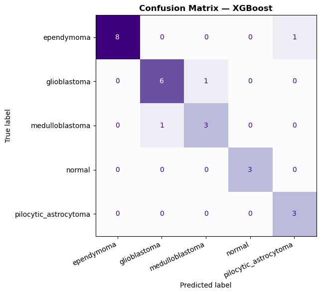

```python
# ── Plot Confusion Matrix ───────────────────────────────────────────
fig, ax = plt.subplots(figsize=(7, 6))
disp = ConfusionMatrixDisplay(confusion_matrix=cm_xgb, display_labels=le.classes_)
disp.plot(ax=ax, colorbar=False, cmap='Purples')
plt.title("Confusion Matrix — XGBoost", fontweight="bold")
plt.xticks(rotation=25, ha="right")
plt.tight_layout()
plt.show()
```

## 13. Final Comparison — All Four Models

```
=======================================================
  Model                    Accuracy     Recall
-------------------------------------------------------
  XGBoost                    88.46%     89.92%
  Random Forest              88.46%     87.78%
  Decision Tree              84.62%     84.92%
  KNN (k=5)                  84.62%     84.92%
=======================================================
```

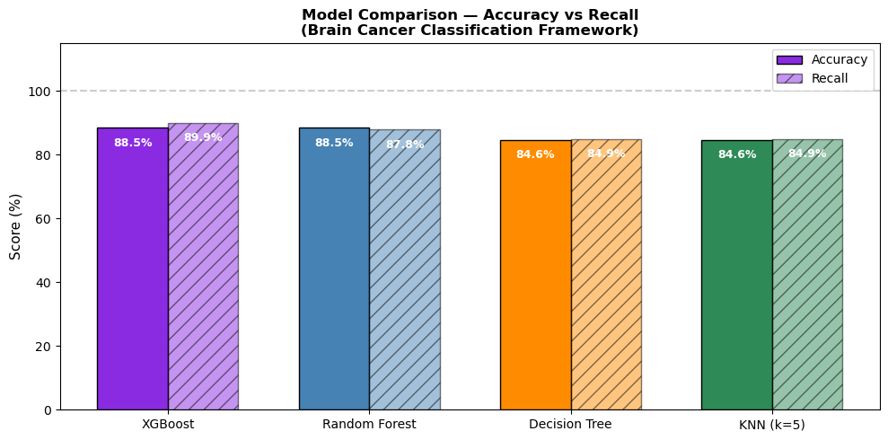

```
For disease detection, RECALL is the most important metric!
Low recall = the model missed actual cancer cases (false negatives).
```

```python
import numpy as np
import matplotlib.pyplot as plt
from sklearn.metrics import accuracy_score, recall_score

# ── Recall model predictions from earlier runs ────────────────────────
y_pred_xgb = xgb.predict(X_test_pca)  # Your new XGBoost model
y_pred_rf  = rf.predict(X_test_pca)
y_pred_dt  = dt.predict(X_test_pca)
y_pred_knn = knn.predict(X_test_pca)

# ── Calculate Accuracy scores ─────────────────────────────────────────
acc_xgb = accuracy_score(y_test, y_pred_xgb) * 100
acc_rf  = accuracy_score(y_test, y_pred_rf) * 100
acc_dt  = accuracy_score(y_test, y_pred_dt) * 100
acc_knn = accuracy_score(y_test, y_pred_knn) * 100

# ── Calculate Recall for each model (macro avg) ───────────────────────
rec_xgb = recall_score(y_test, y_pred_xgb, average='macro') * 100
rec_rf  = recall_score(y_test, y_pred_rf,  average='macro') * 100
rec_dt  = recall_score(y_test, y_pred_dt,  average='macro') * 100
rec_knn = recall_score(y_test, y_pred_knn, average='macro') * 100

# ── Summary table ─────────────────────────────────────────────────────
print("=" * 55)
print(f"  {'Model':<22} {'Accuracy':>10} {'Recall':>10}")
print("-" * 55)
print(f"  {'XGBoost':<22} {acc_xgb:>9.2f}% {rec_xgb:>9.2f}%")
print(f"  {'Random Forest':<22} {acc_rf:>9.2f}% {rec_rf:>9.2f}%")
print(f"  {'Decision Tree':<22} {acc_dt:>9.2f}% {rec_dt:>9.2f}%")
print(f"  {'KNN (k=5)':<22} {acc_knn:>9.2f}% {rec_knn:>9.2f}%")
print("=" * 55)

# ── Bar chart: Accuracy vs Recall side by side ────────────────────────
x      = np.arange(4)  # Changed to 4 to accommodate all models
width  = 0.35
models = ['XGBoost', 'Random Forest', 'Decision Tree', 'KNN (k=5)']

fig, ax = plt.subplots(figsize=(10, 5))
bars_acc = ax.bar(x - width/2, [acc_xgb, acc_rf, acc_dt, acc_knn],
                  width, label='Accuracy', color=['blueviolet', 'steelblue', 'darkorange', 'seagreen'],
                  edgecolor='black')
bars_rec = ax.bar(x + width/2, [rec_xgb, rec_rf, rec_dt, rec_knn],
                  width, label='Recall',   color=['blueviolet', 'steelblue', 'darkorange', 'seagreen'],
                  edgecolor='black', alpha=0.5, hatch='//')

# label each bar with its percentage value
for bar in list(bars_acc) + list(bars_rec):
    ax.text(bar.get_x() + bar.get_width() / 2,
            bar.get_height() - 3,
            f"{bar.get_height():.1f}%",
            ha="center", va="top", fontsize=9, color="white", fontweight="bold")

ax.set_ylim(0, 115)
ax.set_xticks(x)
ax.set_xticklabels(models)
ax.set_ylabel("Score (%)", fontsize=11)
ax.set_title("Model Comparison — Accuracy vs Recall\n(Brain Cancer Classification Framework)",
             fontweight="bold")
ax.legend(fontsize=10, loc="upper right")
ax.axhline(y=100, color="gray", linestyle="--", alpha=0.4)
plt.tight_layout()
plt.show()

print("\nFor disease detection, RECALL is the most important metric!")
print("Low recall = the model missed actual cancer cases (false negatives).")
```

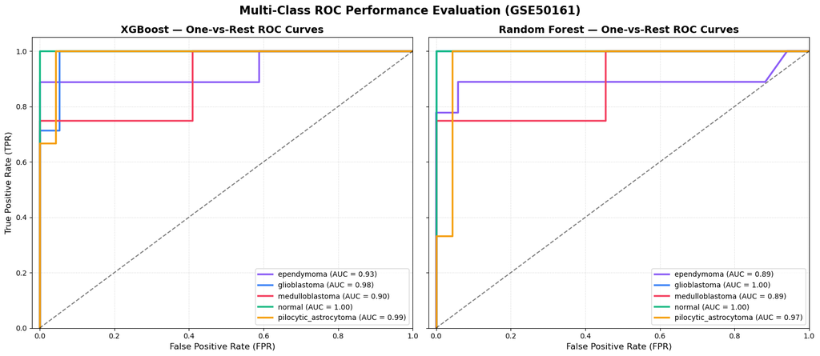

```python
# 1. Binarize the labels for One-vs-Rest calculation
# This converts your multi-class targets into a binary matrix shape (N_samples, N_classes)
classes = list(le.classes_)
n_classes = len(classes)
y_test_binarized = label_binarize(y_test, classes=range(n_classes))

# 2. Extract predicted probabilities for XGBoost and Random Forest
# [:, i] gets the probability vector for class i
y_score_xgb = xgb.predict_proba(X_test_pca)
y_score_rf  = rf.predict_proba(X_test_pca)

# 3. Set up the plotting canvas side-by-side (1 row, 2 columns)
fig, (ax1, ax2) = plt.subplots(1, 2, figsize=(16, 7), sharey=True)

# Colors for your 5 distinct tumor/tissue classes
colors = ['#8b5cf6', '#3b82f6', '#f43f5e', '#10b981', '#f59e0b']

# ── Plot 1: XGBoost ROC Curves ────────────────────────────────────────
for i, color in enumerate(colors):
    fpr, tpr, _ = roc_curve(y_test_binarized[:, i], y_score_xgb[:, i])
    roc_auc = auc(fpr, tpr)
    ax1.plot(fpr, tpr, color=color, lw=2.5,
             label=f'{classes[i]} (AUC = {roc_auc:.2f})')

ax1.plot([0, 1], [0, 1], 'k--', lw=1.5, alpha=0.5) # Random guess baseline
ax1.set_xlim([-0.02, 1.0])
ax1.set_ylim([0.0, 1.05])
ax1.set_xlabel('False Positive Rate (FPR)', fontsize=12)
ax1.set_ylabel('True Positive Rate (TPR)', fontsize=12)
ax1.set_title('XGBoost — One-vs-Rest ROC Curves', fontweight='bold', fontsize=14)
ax1.legend(loc="lower right", fontsize=10)
ax1.grid(True, linestyle=':', alpha=0.6)

# ── Plot 2: Random Forest ROC Curves ──────────────────────────────────
for i, color in enumerate(colors):
    fpr, tpr, _ = roc_curve(y_test_binarized[:, i], y_score_rf[:, i])
    roc_auc = auc(fpr, tpr)
    ax2.plot(fpr, tpr, color=color, lw=2.5,
             label=f'{classes[i]} (AUC = {roc_auc:.2f})')

ax2.plot([0, 1], [0, 1], 'k--', lw=1.5, alpha=0.5) # Random guess baseline
ax2.set_xlim([-0.02, 1.0])
ax2.set_xlabel('False Positive Rate (FPR)', fontsize=12)
ax2.set_title('Random Forest — One-vs-Rest ROC Curves', fontweight='bold', fontsize=14)
ax2.legend(loc="lower right", fontsize=10)
ax2.grid(True, linestyle=':', alpha=0.6)

plt.suptitle('Multi-Class ROC Performance Evaluation (GSE50161)', fontsize=16, fontweight='bold', y=0.98)
plt.tight_layout()
plt.show()
```